# Foundations lab 4 - Data Products

Jeanne McClure

2022-07-10

## 1. Prepare

Install and load library’s needed for analysis.

```r
#load libraries
library(tidyverse)
library(here)
```

## 2. Wrangle

Read in previously saved data

```r
# read in data to explore
data_to_explore <- read_csv(here("data", "data_to_explore.csv"))
```

## Explore

Looked at insights using ggplot What insights did we find?

## Model

Quantify the insights using mathematical models. As highlighted in.[Chapter 3 of Data Science in Education Using R](https://datascienceineducation.com/c03.html), the.**Model**.step of the data science process entails “using statistical models, from simple to complex, to understand trends and patterns in the data.” The authors note that while descriptive statistics and data visualization during the**Explore**step can help us to identify patterns and relationships in our data, statistical models can be used to help us determine if relationships, patterns and trends are actually meaningful.

##### A. Correlation Matrix

There are two efficient ways to create correlation matrices, one that is best for internal use, and one that is best for inclusion in a manuscript. The {corrr} package provides a way to create a correlation matrix in a {tidyverse}-friendly way. Like for the {skimr} package, it can take as little as a line of code to create a correlation matrix. If not familiar, a correlation matrix is a table that presents how *all of the variables* are related to *all of the other variables*.

```r
#install corrr package if this is your first time

# read in library
library(corrr)
```

Look and see if there is a simple correlation between time spent and student achievement.

```r
data_to_explore %>%
  select(proportion_earned, time_spent_hours) %>%
  correlate()
```

```
##
## Correlation method: 'pearson'
## Missing treated using: 'pairwise.complete.obs'
```

```
## # A tibble: 2 × 3
##   term              proportion_earned time_spent_hours
##   <chr>                         <dbl>            <dbl>
## 1 proportion_earned            NA                0.438
## 2 time_spent_hours              0.438           NA
```

For printing purposes,the `fashion()` function can be added for converting a correlation data frame into a matrix with the correlations cleanly formatted (leading zeros removed; spaced for signs) and the diagonal (or any NA) left blank.

```r
#add fashion function
data_to_explore %>%
  select(proportion_earned, time_spent_hours) %>%
  correlate() %>%
  rearrange() %>%
  shave() %>%
  fashion()
```

```
##
## Correlation method: 'pearson'
## Missing treated using: 'pairwise.complete.obs'
```

```
##                term proportion_earned time_spent_hours
## 1 proportion_earned
## 2  time_spent_hours               .44
```

If time allows feel free to add more variables to see if they are related to time spent, sticking to numeric variables. Were your selected variables related to time spent in the course?

##### B. APA Formatted Table

While {corrr} is a nice package to quickly create a correlation matrix, you may wish to create one that is ready to be added directly to a dissertation or journal article. {apaTables} is great for creating more formal forms of output that can be added directly to an APA-formatted manuscript; it also has functionality for regression and other types of model output. It is not as friendly to {tidyverse} functions; first, we need to select only the variables we wish to correlate.

Then, we can use that subset of the variables as the argument to the`apa.cor.table()` function.

Run the following code to create a subset of the larger `data_to_explore` data frame with the variables you wish to correlate, then create a correlation table using `apa.cor.table()`.

```r
#install if this is your first time

# read in apatables library
library(apaTables)

data_to_explore_subset <- data_to_explore %>%
  select(time_spent_hours, proportion_earned, int)

apa.cor.table(data_to_explore_subset)
```

```
##
##
## Means, standard deviations, and correlations with confidence intervals
##
##
##   Variable             M     SD    1           2
##   1. time_spent_hours  30.48 22.72
##
##   2. proportion_earned 0.76  0.25  .44**
##                                    [.37, .50]
##
##   3. int               4.30  0.60  .08         .14**
##                                    [-.01, .16] [.06, .22]
##
##
## Note. M and SD are used to represent mean and standard deviation, respectively.
## Values in square brackets indicate the 95% confidence interval.
## The confidence interval is a plausible range of population correlations
## that could have caused the sample correlation (Cumming, 2014).
##  * indicates p < .05. ** indicates p < .01.
##
```

This may look nice, but how to actually add this into a dissertation or article that you might be interested in publishing?

Read the documentation for `apa.cor.table()` by running `?apa.cor.table()` in the console. Look through the documentation and examples to understand how to output a file with the formatted correlation table, and then run the code to do that with your subset of the `data_to_explore` data frame.

```r
apa.cor.table(data_to_explore_subset, filename = "cor-table.doc")
```

```
##
##
## Means, standard deviations, and correlations with confidence intervals
##
##
##   Variable             M     SD    1           2
##   1. time_spent_hours  30.48 22.72
##
##   2. proportion_earned 0.76  0.25  .44**
##                                    [.37, .50]
##
##   3. int               4.30  0.60  .08         .14**
##                                    [-.01, .16] [.06, .22]
##
##
## Note. M and SD are used to represent mean and standard deviation, respectively.
## Values in square brackets indicate the 95% confidence interval.
## The confidence interval is a plausible range of population correlations
## that could have caused the sample correlation (Cumming, 2014).
##  * indicates p < .05. ** indicates p < .01.
##
```

##### C. Predict Academic Achievement

##### Linear Regression

In brief, a linear regression model involves estimating the relationships between one or more *independent variables* with one dependent variable. Mathematically, it can be written like the following.

$$\operatorname{dependentvar} = \beta_{0} +
\beta_{1}(\operatorname{independentvar}) + \epsilon$$

Does time spent predict grade earned?

```r
lm(proportion_earned ~ time_spent_hours,
   data = data_to_explore)
```

```
##
## Call:
## lm(formula = proportion_earned ~ time_spent_hours, data = data_to_explore)
##
## Coefficients:
##      (Intercept)  time_spent_hours
##         0.624306          0.004792
```

```r
# Add predictor variable for science
lm(proportion_earned ~ time_spent_hours + int,
   data = data_to_explore)
```

```
##
## Call:
## lm(formula = proportion_earned ~ time_spent_hours + int, data = data_to_explore)
##
## Coefficients:
##      (Intercept)  time_spent_hours               int
##         0.449657          0.004255          0.046283
```

We can see that the intercept is now estimated at 0.44, which tells us that when students’ time spent and interest are equal to zero, they are likely fail the course unsurprisingly. Note that that estimate for interest in science is .046, so for every one-unit increase in `int`, we should expect an 5 percentage point increase in their grade.

We can save the output of the function to an object—let’s say `m1`, standing for model 1. We can then use the `summary()` function built into R to view a much more feature-rich summary of the estimated model.

```r
# save the model
m1 <- lm(proportion_earned ~ time_spent_hours + int, data = data_to_explore)
```

Run a summary model for the model you just created called, `m1.`

```r
#run the summary
summary(m1)
```

```
##
## Call:
## lm(formula = proportion_earned ~ time_spent_hours + int, data = data_to_explore)
##
## Residuals:
##      Min       1Q   Median       3Q      Max
## -0.66705 -0.07836  0.05049  0.14695  0.35766
##
## Coefficients:
##                  Estimate Std. Error t value Pr(>|t|)
## (Intercept)      0.449657   0.066488   6.763 3.54e-11 ***
## time_spent_hours 0.004255   0.000410  10.378  < 2e-16 ***
## int              0.046282   0.015364   3.012  0.00271 **
## ---
## Signif. codes:  0 '***' 0.001 '**' 0.01 '*' 0.05 '.' 0.1 ' ' 1
##
## Residual standard error: 0.2142 on 536 degrees of freedom
##   (404 observations deleted due to missingness)
## Multiple R-squared:  0.1859, Adjusted R-squared:  0.1828
## F-statistic: 61.18 on 2 and 536 DF,  p-value: < 2.2e-16
```

##### Summarize predictors

the `summarize()` function from the {dplyr} package used to create summary statistics such as the mean, standard deviation, or the minimum or maximum of a value. At its core, think of `summarize()` as a function that returns a single value (whether it’s a mean, median, standard deviation—whichever!) that summarizes a single column.

```r
data_to_explore %>%
  summarize(mean_interest = mean(int, na.rm = TRUE),
            mean_time = mean(time_spent_hours, na.rm = TRUE))
```

```
## # A tibble: 1 × 2
##   mean_interest mean_time
##           <dbl>     <dbl>
## 1          4.30      30.5
```

The mean value for interest is quite high. If we multiply the estimate relationship between interest and proportion of points earned—0.046—by this, the mean interest across all of the students—we can determine that students’ estimate final grade was 0.046 X 4.3, or **0.197**. For hours spent spent, the average students’ estimate final grade was 0.0042 X 30.48, or **0.128**.

If we add both 0.197 and 0.128 to the intercept, 0.449, that equals 0.774, or about 77%. In other words, a student with average interest in science who spent an average amount of time in the course earned a pretty average grade.

Let’s save this as a nice APA table for possible publication

```r
apa.reg.table(m1, filename = "lm-table.doc")
```

```
##
##
## Regression results using proportion_earned as the criterion
##
##
##         Predictor      b     b_95%_CI beta  beta_95%_CI sr2  sr2_95%_CI     r
##       (Intercept) 0.45** [0.32, 0.58]
##  time_spent_hours 0.00** [0.00, 0.01] 0.41 [0.33, 0.48] .16  [.11, .22] .41**
##               int 0.05** [0.02, 0.08] 0.12 [0.04, 0.19] .01 [-.00, .03] .15**
##
##
##
##              Fit
##
##
##
##      R2 = .186**
##  95% CI[.13,.24]
##
##
## Note. A significant b-weight indicates the beta-weight and semi-partial correlation are also significant.
## b represents unstandardized regression weights. beta indicates the standardized regression weights.
## sr2 represents the semi-partial correlation squared. r represents the zero-order correlation.
## Square brackets are used to enclose the lower and upper limits of a confidence interval.
## * indicates p < .05. ** indicates p < .01.
##
```

```r
#install apaTables if this is your first time - do you remember how?

#load packages
library(apaTables)
# use the {apaTables} package to create a nice regression table that could be used for later publication.
apa.reg.table(m1, filename = "lm-table.doc")
```

```
##
##
## Regression results using proportion_earned as the criterion
##
##
##         Predictor      b     b_95%_CI beta  beta_95%_CI sr2  sr2_95%_CI     r
##       (Intercept) 0.45** [0.32, 0.58]
##  time_spent_hours 0.00** [0.00, 0.01] 0.41 [0.33, 0.48] .16  [.11, .22] .41**
##               int 0.05** [0.02, 0.08] 0.12 [0.04, 0.19] .01 [-.00, .03] .15**
##
##
##
##              Fit
##
##
##
##      R2 = .186**
##  95% CI[.13,.24]
##
##
## Note. A significant b-weight indicates the beta-weight and semi-partial correlation are also significant.
## b represents unstandardized regression weights. beta indicates the standardized regression weights.
## sr2 represents the semi-partial correlation squared. r represents the zero-order correlation.
## Square brackets are used to enclose the lower and upper limits of a confidence interval.
## * indicates p < .05. ** indicates p < .01.
##
```

## Communicate

1. **Select.** Select a group from above, or a new analysis if so motivated, that you think would be interesting or relevant for the target audience and that helps answer our research questions.
2. **Polish.** Create and polish a data visualization and/or data table to communicate your selected findings.
3. **Narrate.** Write a brief narrative (2-3 paragraphs) to accompany your visualization and/or table that includes the following:
   - The question or questions guiding the analysis;
   - The conclusions you’ve reached based on our findings;
   - How your audience might use this information;
   - How you might revisit or improve upon this analysis in the future.

#### **👉 Your Turn** **⤵**

Purpose of this case study is to investigate whether time spent in an online course is predictive of student achievement.

To do this we looked at a simple correlation between time spent and student achievement.

**RQ1**: Do males outperform females in online STEM courses?

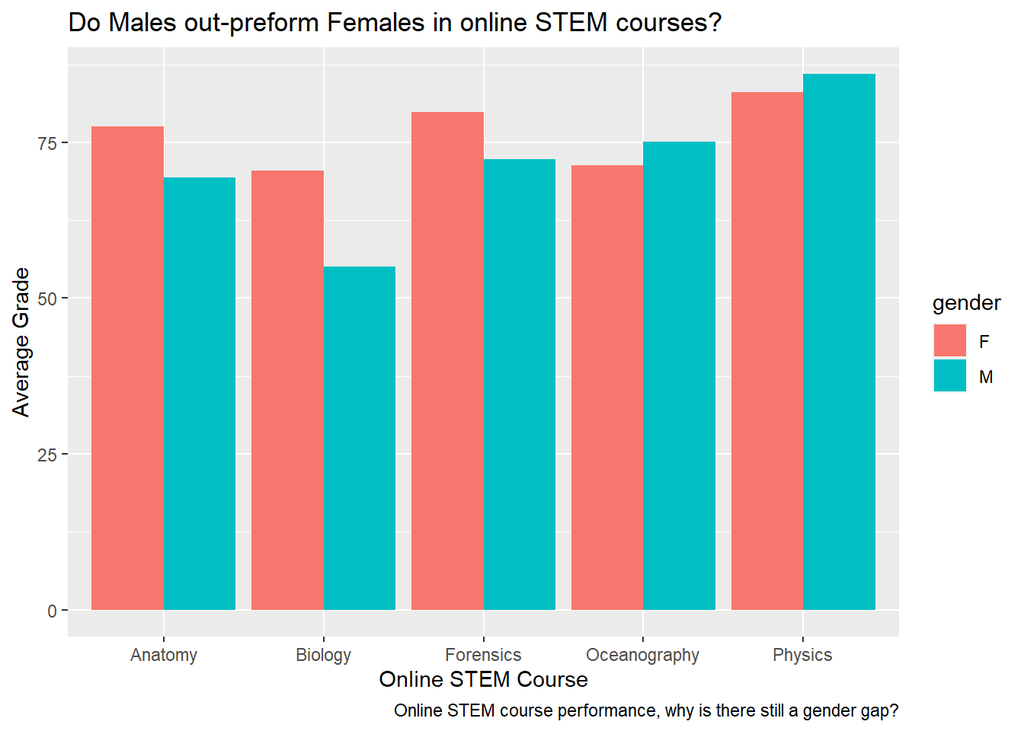

```r
data_viz <- data_to_explore %>%
  select(subject, gender, proportion_earned) %>%  # reduced
  mutate(subject = recode(subject,
                          "AnPhA" = "Anatomy",
                          "BioA" = "Biology",
                          "FrScA" = "Forensics",
                          "OcnA" =  "Oceanography",
                          "PhysA" = "Physics")) %>%
  mutate(grade = proportion_earned * 100) %>%
  # filter(!is.na(gender)) %>%
  na.omit() %>% # removed all NAs instead of just those for gender
  group_by(subject, gender) %>% # grouped by subject and gender
  summarise(grade = mean(grade),
            sd = sd(grade))# calculated mean and sd for grade and saved as grade again

  ggplot(data_viz, aes(x = subject, y = grade,
                          fill = gender)) +
  geom_bar(stat = "identity",
           position = position_dodge()) +
  labs(title = "Do Males out-preform Females in online STEM courses?",
       caption = "Online STEM course performance, why is there still a gender gap?",
       y = "Average Grade",
       x = "Online STEM Course")
```

Knit your data product to a desired output format. This may be a simple - [HTML](https://bookdown.org/yihui/rmarkdown/html-document.html), - [PDF](https://bookdown.org/yihui/rmarkdown/pdf-document.html), or - [MS Word](https://bookdown.org/yihui/rmarkdown/word-document.html) file; or something more complex like - [HTML5 slides](https://bookdown.org/yihui/rmarkdown/ioslides-presentation.html), - [Tufte-style handout](https://bookdown.org/yihui/rmarkdown/tufte-handouts.html), - [dashboard](https://rmarkdown.rstudio.com/flexdashboard/), or - [website](https://bookdown.org/yihui/rmarkdown/rmarkdown-site.html).

You can publish and share from:

- (e.g., via [RPubs](https://rpubs.com/about/getting-started) or
- [GitHub](https://towardsdatascience.com/how-to-create-a-free-github-pages-website-53743d7524e1))